# Week 2 Analysis

## Task 1: Reading the data

Let’s start by reading the data we preprocessed during the wrangling phase:

```r
data <- read.csv(file = "data/andata.csv", header = TRUE)
```

Let’s take look at the shape of the data:

```r
dim(data)
```

```
## [1] 166   7
```

And their structure:

```r
str(data)
```

```
## 'data.frame':    166 obs. of  7 variables:
##  $ gender  : Factor w/ 2 levels "F","M": 1 2 1 2 2 1 2 1 2 1 ...
##  $ Age     : int  53 55 49 53 49 38 50 37 37 42 ...
##  $ Attitude: int  37 31 25 35 37 38 35 29 38 21 ...
##  $ deep    : num  0.97 0.789 0.947 0.947 0.992 ...
##  $ stra    : num  1.08 1 1.12 1 1.24 ...
##  $ surf    : num  0.925 1.134 0.806 0.806 1.015 ...
##  $ Points  : int  25 12 24 10 22 21 21 31 24 26 ...
```

### Explaining the data

This data consists of student records, a collection of variables that describe their learning capacities.

- Gender: the gender of each subject
- Age: the age of each subject
- Attitude: their global attitude towards statistics
- Deep: A score that indicates that the student has a **deep** learning approach
- Stra: A score that indicates that the student has a **strategic** learning approach
- Surf: A score that indicates that the student has a **surface** learning approach
- Points: Exam points that the student scored

## Task 2: Exploratory data analysis

Let’s start by visualizing an overview of the variables:

```r
library(GGally)
```

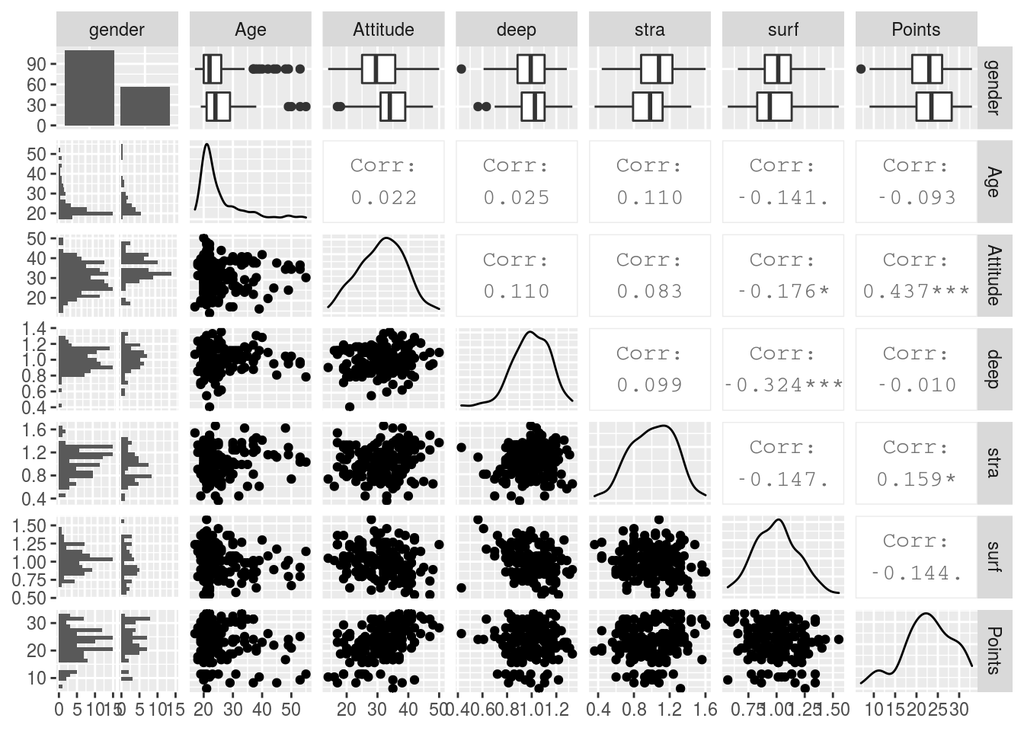

```r
library(ggplot2)

ggpairs(data, mapping = aes(), lower = list(combo = wrap("facethist", bins = 20)))
```

Here we can observe an assortment of pairwise scatterplots, densities, and correlation measurements, between pairs of variables. We can only observe some correlations that stand out amongst those pairs. For instance, variables **surf** and **deep** seem to have some negative correlation (of the magnitude of 0.324). This seems to match our intuition that a student with a deeper learning approach, will have a less superficial (**surf**) attitude towards their learning. We can also observe an important correlation between **Attitude** and **Points**. This means that the more positive the learning attitude of the student, the better they seem to perform in their exams.

## Task 3: Linear Regression

Let’s fit a linear regression model! Let’s be practical and start with a trial model with all 6 variables first, and then select the 3 explanatory variables with highest absolute values of coefficients: this means that we will choose the variables that have the biggest weights in the regression, hence are the most important ones to be used when predicting exam **Points**.

```r
lr <- lm(Points ~ deep + stra + surf + gender+ Age + Attitude, data = data)
summary(lr)
```

```
##
## Call:
## lm(formula = Points ~ deep + stra + surf + gender + Age + Attitude,
##     data = data)
##
## Residuals:
##      Min       1Q   Median       3Q      Max
## -17.4422  -3.0307   0.4267   3.5113  11.5205
##
## Coefficients:
##              Estimate Std. Error t value Pr(>|t|)
## (Intercept) 18.349972   5.219354   3.516 0.000572 ***
## deep        -3.903358   2.896995  -1.347 0.179774
## stra         3.163934   1.727208   1.832 0.068849 .
## surf        -3.150669   2.350764  -1.340 0.182068
## genderM      0.007335   0.934524   0.008 0.993747
## Age         -0.098012   0.053992  -1.815 0.071362 .
## Attitude     0.340279   0.059914   5.679 6.27e-08 ***
## ---
## Signif. codes:  0 '***' 0.001 '**' 0.01 '*' 0.05 '.' 0.1 ' ' 1
##
## Residual standard error: 5.26 on 159 degrees of freedom
## Multiple R-squared:  0.2327, Adjusted R-squared:  0.2038
## F-statistic: 8.038 on 6 and 159 DF,  p-value: 1.376e-07
```

It seems that variables **deep**, **stra** and **surf** are by for the most important ones when trying to predict **Points**. The absolute values of their coefficients are much higher than those of the rest of variables. This means that either they have a positive or a negative effect on the predictions, this effect has the highest weights for these three variables.

Then, next, let’s fit the linear regression model with these three variables: **deep, stra and surf**.

```r
lr <- lm(Points ~ deep + stra + surf, data = data)
summary(lr)
```

```
##
## Call:
## lm(formula = Points ~ deep + stra + surf, data = data)
##
## Residuals:
##      Min       1Q   Median       3Q      Max
## -15.4330  -2.9786   0.4217   4.3700  10.2294
##
## Coefficients:
##             Estimate Std. Error t value Pr(>|t|)
## (Intercept)   26.601      5.087   5.229 5.19e-07 ***
## deep          -2.823      3.196  -0.883   0.3784
## stra           3.434      1.850   1.856   0.0653 .
## surf          -4.558      2.545  -1.791   0.0752 .
## ---
## Signif. codes:  0 '***' 0.001 '**' 0.01 '*' 0.05 '.' 0.1 ' ' 1
##
## Residual standard error: 5.815 on 162 degrees of freedom
## Multiple R-squared:  0.04477,    Adjusted R-squared:  0.02708
## F-statistic: 2.531 on 3 and 162 DF,  p-value: 0.05906
```

Since the explanatory variable **deep** does not have a statistically significant relationship with the target variable, we will remove it from the model and fit the model again without it in the section below.

## Task 4: A closer look at the parameters

Since variable **deep** seems to have a rather high p-value, we can infer that it does not relate significantly with the target variable, so let’s replace it by the **Attitude** variable that has some weight on the regression line, and a very low p-value.

```r
lr <- lm(Points ~  Attitude + stra + surf, data = data)
summary(lr)
```

```
##
## Call:
## lm(formula = Points ~ Attitude + stra + surf, data = data)
##
## Residuals:
##      Min       1Q   Median       3Q      Max
## -17.3445  -3.2624   0.5456   3.7424  10.9133
##
## Coefficients:
##             Estimate Std. Error t value Pr(>|t|)
## (Intercept) 11.00759    3.64446   3.020  0.00293 **
## Attitude     0.33709    0.05744   5.868 2.42e-08 ***
## stra         2.76176    1.68460   1.639  0.10307
## surf        -1.68259    2.23040  -0.754  0.45171
## ---
## Signif. codes:  0 '***' 0.001 '**' 0.01 '*' 0.05 '.' 0.1 ' ' 1
##
## Residual standard error: 5.293 on 162 degrees of freedom
## Multiple R-squared:  0.2084, Adjusted R-squared:  0.1938
## F-statistic: 14.22 on 3 and 162 DF,  p-value: 2.858e-08
```

We can infer several things about the parameters of the model from the above summary. First of all, we have four parameters with their respective coefficient estimates:

- **Attitude:** 0.337
- **stra:** 2.761
- **surf:** -1.682
- **Intercept:** 11.007

Now we can observe a multiple R-squared of 20.84% which means that the fitted regression line explains well about 20.84% of the entire sample population. We also observe a p-value very close to zero (2.858e-08).

## Task 5: Diagnostics

Let’s see how we can validate the assumptions of our model.

First of all, what are the assumptions for a linear regression model?

- The errors are normally distributed
- The errors are independent
- The errors have a constant variance

Using the following diagnostic plots, we will try to validate these assumptions. First, the Residuals vs Fitted:

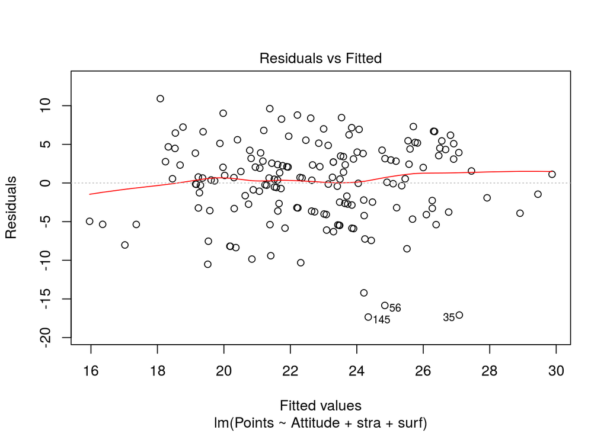

```r
plot(lr, which = 1)
```

Using the Residuals vs Fitted plot we can validate that the variance of the errors is constant. Indeed, since no particular patterns are identifiable in the above scatter plot, we can infer that the variance remains constant throughout the range of fitted values.

Then, the Normal Q-Q:

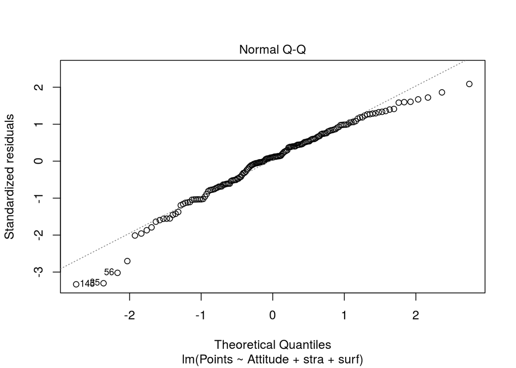

```r
plot(lr, which = 2)
```

Finally, the Residuals vs Leverage:

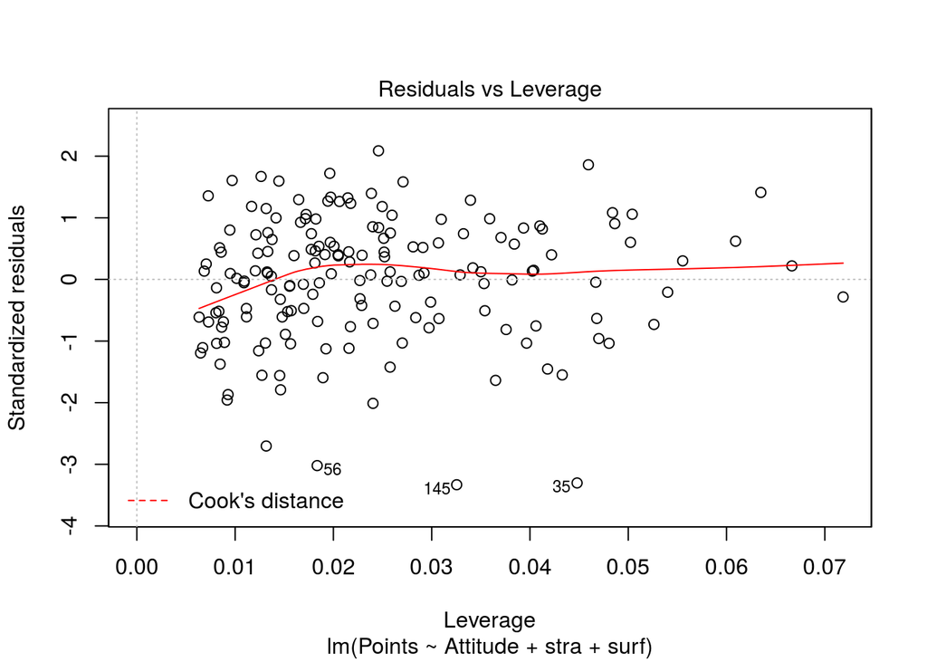

```r
plot(lr, which = 5)
```

Here we can examine if there are any outliers in our data that have an imbalanced, high leverage on the regression resutls. But as we can observe in our plot, there is a higher concentration of values on the left side, but there are quite few values on the right side as well with higher leverage. Still this seems to be within the variance of the original data distribution, and we don’t see any outlying observations with high leverage.